# Risk Factor Analysis

## Outcome Variable

**Outcome Variable:** y_rate_wtkg

## Predictor Variables

**Intervention Variable:** predfeed6

**Adjustment Set:**

- arm
- sex
- month
- brthmon
- W_mage
- meducyrs
- feducyrs
- hhwealth_quart
- hfoodsec
- W_mhtcm
- W_mwtkg
- W_mbmi
- vagbrth
- W_birthwt
- W_birthlen
- single
- W_nrooms
- impfloor
- impsan
- safeh20
- delta_W_mage
- delta_meducyrs
- delta_feducyrs
- delta_hhwealth_quart
- delta_hfoodsec
- delta_W_mhtcm
- delta_W_mwtkg
- delta_W_mbmi
- delta_vagbrth
- delta_W_birthwt
- delta_W_birthlen
- delta_single
- delta_W_nrooms
- delta_impfloor
- delta_impsan
- delta_safeh20

## Stratifying Variables

The analysis was stratified on these variable(s):

- agecat
- studyid
- country

## Data Summary

| agecat | studyid | country | predfeed6 | n_cell | n | outcome_variable |
| --- | --- | --- | --- | --- | --- | --- |
| 0-3 months | ki0047075b-MAL-ED | BANGLADESH | 1 | 84 | 230 | y_rate_wtkg |
| 0-3 months | ki0047075b-MAL-ED | BANGLADESH | 0 | 146 | 230 | y_rate_wtkg |
| 0-3 months | ki0047075b-MAL-ED | BRAZIL | 1 | 30 | 210 | y_rate_wtkg |
| 0-3 months | ki0047075b-MAL-ED | BRAZIL | 0 | 180 | 210 | y_rate_wtkg |
| 0-3 months | ki0047075b-MAL-ED | INDIA | 1 | 11 | 216 | y_rate_wtkg |
| 0-3 months | ki0047075b-MAL-ED | INDIA | 0 | 205 | 216 | y_rate_wtkg |
| 0-3 months | ki0047075b-MAL-ED | NEPAL | 1 | 11 | 219 | y_rate_wtkg |
| 0-3 months | ki0047075b-MAL-ED | NEPAL | 0 | 208 | 219 | y_rate_wtkg |
| 0-3 months | ki0047075b-MAL-ED | PERU | 1 | 92 | 270 | y_rate_wtkg |
| 0-3 months | ki0047075b-MAL-ED | PERU | 0 | 178 | 270 | y_rate_wtkg |
| 0-3 months | ki0047075b-MAL-ED | SOUTH AFRICA | 1 | 3 | 234 | y_rate_wtkg |
| 0-3 months | ki0047075b-MAL-ED | SOUTH AFRICA | 0 | 231 | 234 | y_rate_wtkg |
| 0-3 months | ki0047075b-MAL-ED | TANZANIA, UNITED REPUBLIC OF | 1 | 1 | 219 | y_rate_wtkg |
| 0-3 months | ki0047075b-MAL-ED | TANZANIA, UNITED REPUBLIC OF | 0 | 218 | 219 | y_rate_wtkg |
| 0-3 months | ki1000109-EE | PAKISTAN | 1 | 35 | 39 | y_rate_wtkg |
| 0-3 months | ki1000109-EE | PAKISTAN | 0 | 4 | 39 | y_rate_wtkg |
| 0-3 months | ki1113344-GMS-Nepal | NEPAL | 1 | 368 | 501 | y_rate_wtkg |
| 0-3 months | ki1113344-GMS-Nepal | NEPAL | 0 | 133 | 501 | y_rate_wtkg |
| 0-3 months | kiGH5241-JiVitA-3 | BANGLADESH | 1 | 9440 | 12207 | y_rate_wtkg |
| 0-3 months | kiGH5241-JiVitA-3 | BANGLADESH | 0 | 2767 | 12207 | y_rate_wtkg |
| 0-3 months | kiGH5241-JiVitA-4 | BANGLADESH | 1 | 2056 | 2449 | y_rate_wtkg |
| 0-3 months | kiGH5241-JiVitA-4 | BANGLADESH | 0 | 393 | 2449 | y_rate_wtkg |
| 3-6 months | ki0047075b-MAL-ED | BANGLADESH | 1 | 81 | 224 | y_rate_wtkg |
| 3-6 months | ki0047075b-MAL-ED | BANGLADESH | 0 | 143 | 224 | y_rate_wtkg |
| 3-6 months | ki0047075b-MAL-ED | BRAZIL | 1 | 30 | 208 | y_rate_wtkg |
| 3-6 months | ki0047075b-MAL-ED | BRAZIL | 0 | 178 | 208 | y_rate_wtkg |
| 3-6 months | ki0047075b-MAL-ED | INDIA | 1 | 11 | 213 | y_rate_wtkg |
| 3-6 months | ki0047075b-MAL-ED | INDIA | 0 | 202 | 213 | y_rate_wtkg |
| 3-6 months | ki0047075b-MAL-ED | NEPAL | 1 | 11 | 222 | y_rate_wtkg |
| 3-6 months | ki0047075b-MAL-ED | NEPAL | 0 | 211 | 222 | y_rate_wtkg |

[output cut: 150 more lines]

The following strata were considered:

- agecat: 0-3 months, studyid: ki0047075b-MAL-ED, country: BANGLADESH
- agecat: 0-3 months, studyid: ki0047075b-MAL-ED, country: BRAZIL
- agecat: 0-3 months, studyid: ki0047075b-MAL-ED, country: INDIA
- agecat: 0-3 months, studyid: ki0047075b-MAL-ED, country: NEPAL
- agecat: 0-3 months, studyid: ki0047075b-MAL-ED, country: PERU
- agecat: 0-3 months, studyid: ki0047075b-MAL-ED, country: SOUTH AFRICA
- agecat: 0-3 months, studyid: ki0047075b-MAL-ED, country: TANZANIA, UNITED REPUBLIC OF
- agecat: 0-3 months, studyid: ki1000109-EE, country: PAKISTAN
- agecat: 0-3 months, studyid: ki1113344-GMS-Nepal, country: NEPAL
- agecat: 0-3 months, studyid: kiGH5241-JiVitA-3, country: BANGLADESH
- agecat: 0-3 months, studyid: kiGH5241-JiVitA-4, country: BANGLADESH
- agecat: 12-15 months, studyid: ki0047075b-MAL-ED, country: BANGLADESH
- agecat: 12-15 months, studyid: ki0047075b-MAL-ED, country: BRAZIL
- agecat: 12-15 months, studyid: ki0047075b-MAL-ED, country: INDIA
- agecat: 12-15 months, studyid: ki0047075b-MAL-ED, country: NEPAL
- agecat: 12-15 months, studyid: ki0047075b-MAL-ED, country: PERU
- agecat: 12-15 months, studyid: ki0047075b-MAL-ED, country: SOUTH AFRICA
- agecat: 12-15 months, studyid: ki0047075b-MAL-ED, country: TANZANIA, UNITED REPUBLIC OF
- agecat: 12-15 months, studyid: ki1000109-EE, country: PAKISTAN
- agecat: 12-15 months, studyid: ki1000304b-SAS-FoodSuppl, country: INDIA
- agecat: 12-15 months, studyid: ki1113344-GMS-Nepal, country: NEPAL
- agecat: 12-15 months, studyid: ki1148112-LCNI-5, country: MALAWI
- agecat: 12-15 months, studyid: kiGH5241-JiVitA-4, country: BANGLADESH
- agecat: 15-18 months, studyid: ki0047075b-MAL-ED, country: BANGLADESH
- agecat: 15-18 months, studyid: ki0047075b-MAL-ED, country: BRAZIL
- agecat: 15-18 months, studyid: ki0047075b-MAL-ED, country: INDIA
- agecat: 15-18 months, studyid: ki0047075b-MAL-ED, country: NEPAL
- agecat: 15-18 months, studyid: ki0047075b-MAL-ED, country: PERU
- agecat: 15-18 months, studyid: ki0047075b-MAL-ED, country: SOUTH AFRICA
- agecat: 15-18 months, studyid: ki0047075b-MAL-ED, country: TANZANIA, UNITED REPUBLIC OF
- agecat: 15-18 months, studyid: ki1000109-EE, country: PAKISTAN
- agecat: 15-18 months, studyid: ki1000304b-SAS-FoodSuppl, country: INDIA
- agecat: 15-18 months, studyid: ki1113344-GMS-Nepal, country: NEPAL
- agecat: 15-18 months, studyid: ki1148112-LCNI-5, country: MALAWI
- agecat: 15-18 months, studyid: kiGH5241-JiVitA-4, country: BANGLADESH
- agecat: 18-21 months, studyid: ki0047075b-MAL-ED, country: BANGLADESH
- agecat: 18-21 months, studyid: ki0047075b-MAL-ED, country: BRAZIL
- agecat: 18-21 months, studyid: ki0047075b-MAL-ED, country: INDIA
- agecat: 18-21 months, studyid: ki0047075b-MAL-ED, country: NEPAL
- agecat: 18-21 months, studyid: ki0047075b-MAL-ED, country: PERU
- agecat: 18-21 months, studyid: ki0047075b-MAL-ED, country: SOUTH AFRICA
- agecat: 18-21 months, studyid: ki0047075b-MAL-ED, country: TANZANIA, UNITED REPUBLIC OF
- agecat: 18-21 months, studyid: ki1000109-EE, country: PAKISTAN
- agecat: 18-21 months, studyid: ki1113344-GMS-Nepal, country: NEPAL
- agecat: 18-21 months, studyid: ki1148112-LCNI-5, country: MALAWI
- agecat: 21-24 months, studyid: ki0047075b-MAL-ED, country: BANGLADESH
- agecat: 21-24 months, studyid: ki0047075b-MAL-ED, country: BRAZIL
- agecat: 21-24 months, studyid: ki0047075b-MAL-ED, country: INDIA
- agecat: 21-24 months, studyid: ki0047075b-MAL-ED, country: NEPAL
- agecat: 21-24 months, studyid: ki0047075b-MAL-ED, country: PERU
- agecat: 21-24 months, studyid: ki0047075b-MAL-ED, country: SOUTH AFRICA
- agecat: 21-24 months, studyid: ki0047075b-MAL-ED, country: TANZANIA, UNITED REPUBLIC OF
- agecat: 21-24 months, studyid: ki1000109-EE, country: PAKISTAN
- agecat: 21-24 months, studyid: ki1113344-GMS-Nepal, country: NEPAL
- agecat: 21-24 months, studyid: ki1148112-LCNI-5, country: MALAWI
- agecat: 3-6 months, studyid: ki0047075b-MAL-ED, country: BANGLADESH
- agecat: 3-6 months, studyid: ki0047075b-MAL-ED, country: BRAZIL
- agecat: 3-6 months, studyid: ki0047075b-MAL-ED, country: INDIA
- agecat: 3-6 months, studyid: ki0047075b-MAL-ED, country: NEPAL
- agecat: 3-6 months, studyid: ki0047075b-MAL-ED, country: PERU
- agecat: 3-6 months, studyid: ki0047075b-MAL-ED, country: SOUTH AFRICA
- agecat: 3-6 months, studyid: ki0047075b-MAL-ED, country: TANZANIA, UNITED REPUBLIC OF
- agecat: 3-6 months, studyid: ki1000109-EE, country: PAKISTAN
- agecat: 3-6 months, studyid: ki1113344-GMS-Nepal, country: NEPAL
- agecat: 3-6 months, studyid: kiGH5241-JiVitA-3, country: BANGLADESH
- agecat: 3-6 months, studyid: kiGH5241-JiVitA-4, country: BANGLADESH
- agecat: 6-9 months, studyid: ki0047075b-MAL-ED, country: BANGLADESH
- agecat: 6-9 months, studyid: ki0047075b-MAL-ED, country: BRAZIL
- agecat: 6-9 months, studyid: ki0047075b-MAL-ED, country: INDIA
- agecat: 6-9 months, studyid: ki0047075b-MAL-ED, country: NEPAL
- agecat: 6-9 months, studyid: ki0047075b-MAL-ED, country: PERU
- agecat: 6-9 months, studyid: ki0047075b-MAL-ED, country: SOUTH AFRICA
- agecat: 6-9 months, studyid: ki0047075b-MAL-ED, country: TANZANIA, UNITED REPUBLIC OF
- agecat: 6-9 months, studyid: ki1000109-EE, country: PAKISTAN
- agecat: 6-9 months, studyid: ki1000304b-SAS-FoodSuppl, country: INDIA
- agecat: 6-9 months, studyid: ki1113344-GMS-Nepal, country: NEPAL
- agecat: 6-9 months, studyid: ki1148112-LCNI-5, country: MALAWI
- agecat: 6-9 months, studyid: kiGH5241-JiVitA-4, country: BANGLADESH
- agecat: 9-12 months, studyid: ki0047075b-MAL-ED, country: BANGLADESH
- agecat: 9-12 months, studyid: ki0047075b-MAL-ED, country: BRAZIL
- agecat: 9-12 months, studyid: ki0047075b-MAL-ED, country: INDIA
- agecat: 9-12 months, studyid: ki0047075b-MAL-ED, country: NEPAL
- agecat: 9-12 months, studyid: ki0047075b-MAL-ED, country: PERU
- agecat: 9-12 months, studyid: ki0047075b-MAL-ED, country: SOUTH AFRICA
- agecat: 9-12 months, studyid: ki0047075b-MAL-ED, country: TANZANIA, UNITED REPUBLIC OF
- agecat: 9-12 months, studyid: ki1000109-EE, country: PAKISTAN
- agecat: 9-12 months, studyid: ki1000304b-SAS-FoodSuppl, country: INDIA
- agecat: 9-12 months, studyid: ki1113344-GMS-Nepal, country: NEPAL
- agecat: 9-12 months, studyid: ki1148112-LCNI-5, country: MALAWI
- agecat: 9-12 months, studyid: kiGH5241-JiVitA-4, country: BANGLADESH

### Dropped Strata

- agecat: 0-3 months, studyid: ki0047075b-MAL-ED, country: SOUTH AFRICA
- agecat: 0-3 months, studyid: ki0047075b-MAL-ED, country: TANZANIA, UNITED REPUBLIC OF
- agecat: 0-3 months, studyid: ki1000109-EE, country: PAKISTAN
- agecat: 3-6 months, studyid: ki0047075b-MAL-ED, country: SOUTH AFRICA
- agecat: 3-6 months, studyid: ki0047075b-MAL-ED, country: TANZANIA, UNITED REPUBLIC OF
- agecat: 3-6 months, studyid: ki1000109-EE, country: PAKISTAN
- agecat: 6-9 months, studyid: ki0047075b-MAL-ED, country: SOUTH AFRICA
- agecat: 6-9 months, studyid: ki0047075b-MAL-ED, country: TANZANIA, UNITED REPUBLIC OF
- agecat: 6-9 months, studyid: ki1000304b-SAS-FoodSuppl, country: INDIA
- agecat: 9-12 months, studyid: ki0047075b-MAL-ED, country: SOUTH AFRICA
- agecat: 9-12 months, studyid: ki0047075b-MAL-ED, country: TANZANIA, UNITED REPUBLIC OF
- agecat: 9-12 months, studyid: ki1000304b-SAS-FoodSuppl, country: INDIA
- agecat: 12-15 months, studyid: ki0047075b-MAL-ED, country: SOUTH AFRICA
- agecat: 12-15 months, studyid: ki0047075b-MAL-ED, country: TANZANIA, UNITED REPUBLIC OF
- agecat: 12-15 months, studyid: ki1000304b-SAS-FoodSuppl, country: INDIA
- agecat: 12-15 months, studyid: ki1148112-LCNI-5, country: MALAWI
- agecat: 15-18 months, studyid: ki0047075b-MAL-ED, country: SOUTH AFRICA
- agecat: 15-18 months, studyid: ki0047075b-MAL-ED, country: TANZANIA, UNITED REPUBLIC OF
- agecat: 15-18 months, studyid: ki1000304b-SAS-FoodSuppl, country: INDIA
- agecat: 15-18 months, studyid: ki1148112-LCNI-5, country: MALAWI
- agecat: 18-21 months, studyid: ki0047075b-MAL-ED, country: SOUTH AFRICA
- agecat: 18-21 months, studyid: ki0047075b-MAL-ED, country: TANZANIA, UNITED REPUBLIC OF
- agecat: 21-24 months, studyid: ki0047075b-MAL-ED, country: SOUTH AFRICA
- agecat: 21-24 months, studyid: ki0047075b-MAL-ED, country: TANZANIA, UNITED REPUBLIC OF
- agecat: 21-24 months, studyid: ki1000109-EE, country: PAKISTAN

## Methods Detail

We’re interested in the causal parameters $E[Y_a]$ for all values of $a \in \mathcal{A}$. These parameters represent the mean outcome if, possibly contrary to fact, we intervened to set all units to have $A=a$. Under the randomization and positivity assumptions, these are identified by the statistical parameters $\psi_a=E_W[E_{Y|A,W}(Y|A=a,W)]$. In addition, we’re interested in the mean of $Y$, $E[Y]$ under no intervention (the observed mean). We will estimate these parameters by using SuperLearner to fit the relevant likelihood factors – $E_{Y|A,W}(Y|A=a,W)$ and $p(A=a|W)$, and then updating our likelihood fit using a joint TMLE.

For unadjusted analyses ($W=\{\}$), initial likelihoods were estimated using Lrnr_glm to estimate the simple $E(Y|A)$ and Lrnr_mean to estimate $p(A)$. For adjusted analyses, a small library containing Lrnr_glmnet, Lrnr_xgboost, and Lrnr_mean was used.

# Results Detail

## Results Plots

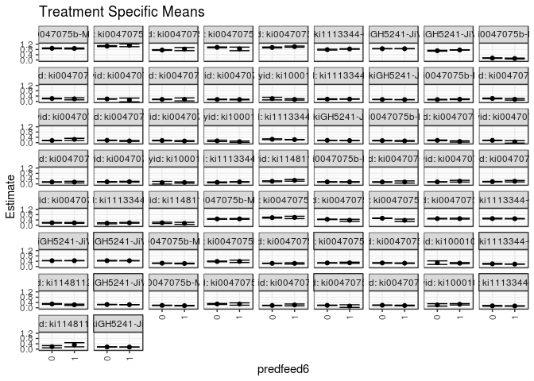

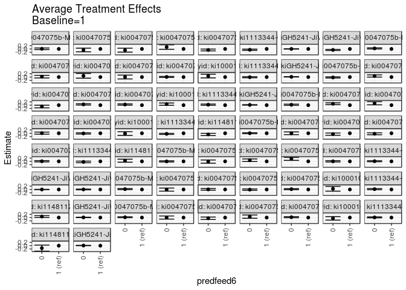

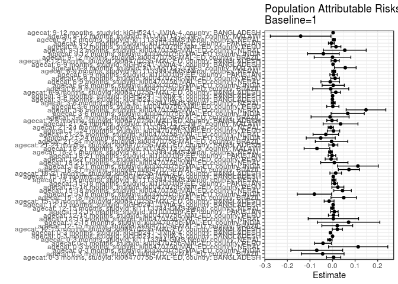

## Results Table

### Parameter: TSM

| agecat | studyid | country | intervention_level | baseline_level | estimate | ci_lower | ci_upper |
| --- | --- | --- | --- | --- | --- | --- | --- |
| 0-3 months | ki0047075b-MAL-ED | BANGLADESH | 1 | NA | 0.8765649 | 0.8388928 | 0.9142369 |
| 0-3 months | ki0047075b-MAL-ED | BANGLADESH | 0 | NA | 0.8852676 | 0.8539781 | 0.9165570 |
| 0-3 months | ki0047075b-MAL-ED | BRAZIL | 1 | NA | 1.1139823 | 1.0096093 | 1.2183554 |
| 0-3 months | ki0047075b-MAL-ED | BRAZIL | 0 | NA | 1.0530792 | 1.0169424 | 1.0892160 |
| 0-3 months | ki0047075b-MAL-ED | INDIA | 1 | NA | 0.8314182 | 0.7136503 | 0.9491861 |
| 0-3 months | ki0047075b-MAL-ED | INDIA | 0 | NA | 0.7590807 | 0.7352712 | 0.7828902 |
| 0-3 months | ki0047075b-MAL-ED | NEPAL | 1 | NA | 0.8434550 | 0.7095478 | 0.9773622 |
| 0-3 months | ki0047075b-MAL-ED | NEPAL | 0 | NA | 0.9591849 | 0.9309837 | 0.9873861 |
| 0-3 months | ki0047075b-MAL-ED | PERU | 1 | NA | 1.0143633 | 0.9706417 | 1.0580849 |
| 0-3 months | ki0047075b-MAL-ED | PERU | 0 | NA | 0.9516447 | 0.9184987 | 0.9847908 |
| 0-3 months | ki1113344-GMS-Nepal | NEPAL | 1 | NA | 0.8384129 | 0.8189188 | 0.8579071 |
| 0-3 months | ki1113344-GMS-Nepal | NEPAL | 0 | NA | 0.7874599 | 0.7533765 | 0.8215433 |
| 0-3 months | kiGH5241-JiVitA-3 | BANGLADESH | 1 | NA | 0.8566776 | 0.8526629 | 0.8606922 |
| 0-3 months | kiGH5241-JiVitA-3 | BANGLADESH | 0 | NA | 0.8570901 | 0.8501764 | 0.8640038 |
| 0-3 months | kiGH5241-JiVitA-4 | BANGLADESH | 1 | NA | 0.7629343 | 0.7482993 | 0.7775693 |
| 0-3 months | kiGH5241-JiVitA-4 | BANGLADESH | 0 | NA | 0.7040269 | 0.6727376 | 0.7353161 |
| 3-6 months | ki0047075b-MAL-ED | BANGLADESH | 1 | NA | 0.4776798 | 0.4516367 | 0.5037229 |
| 3-6 months | ki0047075b-MAL-ED | BANGLADESH | 0 | NA | 0.4749958 | 0.4521241 | 0.4978676 |
| 3-6 months | ki0047075b-MAL-ED | BRAZIL | 1 | NA | 0.5890076 | 0.4990880 | 0.6789272 |
| 3-6 months | ki0047075b-MAL-ED | BRAZIL | 0 | NA | 0.5744159 | 0.5401085 | 0.6087234 |
| 3-6 months | ki0047075b-MAL-ED | INDIA | 1 | NA | 0.3750252 | 0.3003421 | 0.4497084 |
| 3-6 months | ki0047075b-MAL-ED | INDIA | 0 | NA | 0.4435044 | 0.4249567 | 0.4620520 |
| 3-6 months | ki0047075b-MAL-ED | NEPAL | 1 | NA | 0.3729685 | 0.2838058 | 0.4621312 |
| 3-6 months | ki0047075b-MAL-ED | NEPAL | 0 | NA | 0.5260230 | 0.5048359 | 0.5472100 |
| 3-6 months | ki0047075b-MAL-ED | PERU | 1 | NA | 0.4973956 | 0.4647734 | 0.5300177 |
| 3-6 months | ki0047075b-MAL-ED | PERU | 0 | NA | 0.4992828 | 0.4756670 | 0.5228987 |
| 3-6 months | ki1113344-GMS-Nepal | NEPAL | 1 | NA | 0.4938006 | 0.4778727 | 0.5097284 |
| 3-6 months | ki1113344-GMS-Nepal | NEPAL | 0 | NA | 0.5040900 | 0.4753099 | 0.5328700 |
| 3-6 months | kiGH5241-JiVitA-3 | BANGLADESH | 1 | NA | 0.4405543 | 0.4363667 | 0.4447419 |
| 3-6 months | kiGH5241-JiVitA-3 | BANGLADESH | 0 | NA | 0.4392863 | 0.4310049 | 0.4475677 |

[output cut: 100 more lines]

### Parameter: E(Y)

| agecat | studyid | country | intervention_level | baseline_level | estimate | ci_lower | ci_upper |
| --- | --- | --- | --- | --- | --- | --- | --- |
| 0-3 months | ki0047075b-MAL-ED | BANGLADESH | NA | NA | 0.8815161 | 0.8573098 | 0.9057224 |
| 0-3 months | ki0047075b-MAL-ED | BRAZIL | NA | NA | 1.0702868 | 1.0355019 | 1.1050717 |
| 0-3 months | ki0047075b-MAL-ED | INDIA | NA | NA | 0.7615268 | 0.7382819 | 0.7847718 |
| 0-3 months | ki0047075b-MAL-ED | NEPAL | NA | NA | 0.9570869 | 0.9295107 | 0.9846631 |
| 0-3 months | ki0047075b-MAL-ED | PERU | NA | NA | 0.9722590 | 0.9463823 | 0.9981357 |
| 0-3 months | ki1113344-GMS-Nepal | NEPAL | NA | NA | 0.8262343 | 0.8091204 | 0.8433482 |
| 0-3 months | kiGH5241-JiVitA-3 | BANGLADESH | NA | NA | 0.8567813 | 0.8531554 | 0.8604071 |
| 0-3 months | kiGH5241-JiVitA-4 | BANGLADESH | NA | NA | 0.7536287 | 0.7402358 | 0.7670217 |
| 3-6 months | ki0047075b-MAL-ED | BANGLADESH | NA | NA | 0.4752798 | 0.4582021 | 0.4923576 |
| 3-6 months | ki0047075b-MAL-ED | BRAZIL | NA | NA | 0.5781976 | 0.5469697 | 0.6094254 |
| 3-6 months | ki0047075b-MAL-ED | INDIA | NA | NA | 0.4421852 | 0.4242493 | 0.4601211 |
| 3-6 months | ki0047075b-MAL-ED | NEPAL | NA | NA | 0.5212498 | 0.5005373 | 0.5419623 |
| 3-6 months | ki0047075b-MAL-ED | PERU | NA | NA | 0.4986791 | 0.4796733 | 0.5176848 |
| 3-6 months | ki1113344-GMS-Nepal | NEPAL | NA | NA | 0.4969184 | 0.4830319 | 0.5108048 |
| 3-6 months | kiGH5241-JiVitA-3 | BANGLADESH | NA | NA | 0.4401107 | 0.4363074 | 0.4439140 |
| 3-6 months | kiGH5241-JiVitA-4 | BANGLADESH | NA | NA | 0.4390246 | 0.4301757 | 0.4478736 |
| 6-9 months | ki0047075b-MAL-ED | BANGLADESH | NA | NA | 0.2415793 | 0.2267676 | 0.2563910 |
| 6-9 months | ki0047075b-MAL-ED | BRAZIL | NA | NA | 0.3831499 | 0.3570859 | 0.4092138 |
| 6-9 months | ki0047075b-MAL-ED | INDIA | NA | NA | 0.2373787 | 0.2225426 | 0.2522148 |
| 6-9 months | ki0047075b-MAL-ED | NEPAL | NA | NA | 0.2701634 | 0.2553060 | 0.2850207 |
| 6-9 months | ki0047075b-MAL-ED | PERU | NA | NA | 0.2613933 | 0.2459015 | 0.2768851 |
| 6-9 months | ki1000109-EE | PAKISTAN | NA | NA | 0.2545881 | 0.2127069 | 0.2964693 |
| 6-9 months | ki1113344-GMS-Nepal | NEPAL | NA | NA | 0.1872663 | 0.1750716 | 0.1994611 |
| 6-9 months | ki1148112-LCNI-5 | MALAWI | NA | NA | 0.2829175 | 0.2578313 | 0.3080037 |
| 6-9 months | kiGH5241-JiVitA-4 | BANGLADESH | NA | NA | 0.2387113 | 0.2332818 | 0.2441408 |
| 9-12 months | ki0047075b-MAL-ED | BANGLADESH | NA | NA | 0.1745300 | 0.1605119 | 0.1885482 |
| 9-12 months | ki0047075b-MAL-ED | BRAZIL | NA | NA | 0.2845923 | 0.2527896 | 0.3163950 |
| 9-12 months | ki0047075b-MAL-ED | INDIA | NA | NA | 0.1775294 | 0.1625008 | 0.1925581 |
| 9-12 months | ki0047075b-MAL-ED | NEPAL | NA | NA | 0.1836863 | 0.1687462 | 0.1986264 |
| 9-12 months | ki0047075b-MAL-ED | PERU | NA | NA | 0.1874806 | 0.1721694 | 0.2027919 |
| 9-12 months | ki1000109-EE | PAKISTAN | NA | NA | 0.2597774 | 0.2129342 | 0.3066206 |
| 9-12 months | ki1113344-GMS-Nepal | NEPAL | NA | NA | 0.1419417 | 0.1290817 | 0.1548016 |
| 9-12 months | ki1148112-LCNI-5 | MALAWI | NA | NA | 0.1849664 | 0.1167599 | 0.2531730 |
| 9-12 months | kiGH5241-JiVitA-4 | BANGLADESH | NA | NA | 0.1546030 | 0.1501980 | 0.1590079 |
| 12-15 months | ki0047075b-MAL-ED | BANGLADESH | NA | NA | 0.1360408 | 0.1198127 | 0.1522689 |
| 12-15 months | ki0047075b-MAL-ED | BRAZIL | NA | NA | 0.2101946 | 0.1853699 | 0.2350192 |
| 12-15 months | ki0047075b-MAL-ED | INDIA | NA | NA | 0.1767774 | 0.1598803 | 0.1936745 |
| 12-15 months | ki0047075b-MAL-ED | NEPAL | NA | NA | 0.1491675 | 0.1320356 | 0.1662994 |
| 12-15 months | ki0047075b-MAL-ED | PERU | NA | NA | 0.1417390 | 0.1250455 | 0.1584325 |
| 12-15 months | ki1000109-EE | PAKISTAN | NA | NA | 0.1548294 | 0.1084427 | 0.2012160 |
| 12-15 months | ki1113344-GMS-Nepal | NEPAL | NA | NA | 0.1722034 | 0.1587499 | 0.1856570 |
| 12-15 months | kiGH5241-JiVitA-4 | BANGLADESH | NA | NA | 0.1301049 | 0.1256802 | 0.1345296 |
| 15-18 months | ki0047075b-MAL-ED | BANGLADESH | NA | NA | 0.1422772 | 0.1262424 | 0.1583121 |
| 15-18 months | ki0047075b-MAL-ED | BRAZIL | NA | NA | 0.2034195 | 0.1767881 | 0.2300509 |
| 15-18 months | ki0047075b-MAL-ED | INDIA | NA | NA | 0.1652193 | 0.1495522 | 0.1808865 |
| 15-18 months | ki0047075b-MAL-ED | NEPAL | NA | NA | 0.1725504 | 0.1563874 | 0.1887134 |
| 15-18 months | ki0047075b-MAL-ED | PERU | NA | NA | 0.1461889 | 0.1273267 | 0.1650511 |
| 15-18 months | ki1000109-EE | PAKISTAN | NA | NA | 0.0830902 | 0.0429076 | 0.1232727 |
| 15-18 months | ki1113344-GMS-Nepal | NEPAL | NA | NA | 0.2320613 | 0.2164969 | 0.2476258 |
| 15-18 months | kiGH5241-JiVitA-4 | BANGLADESH | NA | NA | 0.1596440 | 0.1546004 | 0.1646877 |
| 18-21 months | ki0047075b-MAL-ED | BANGLADESH | NA | NA | 0.1436485 | 0.1262881 | 0.1610088 |
| 18-21 months | ki0047075b-MAL-ED | BRAZIL | NA | NA | 0.1606491 | 0.1365241 | 0.1847741 |
| 18-21 months | ki0047075b-MAL-ED | INDIA | NA | NA | 0.1695319 | 0.1543435 | 0.1847203 |
| 18-21 months | ki0047075b-MAL-ED | NEPAL | NA | NA | 0.1462090 | 0.1281722 | 0.1642458 |
| 18-21 months | ki0047075b-MAL-ED | PERU | NA | NA | 0.1615652 | 0.1425950 | 0.1805355 |
| 18-21 months | ki1000109-EE | PAKISTAN | NA | NA | 0.1065643 | 0.0620028 | 0.1511258 |
| 18-21 months | ki1113344-GMS-Nepal | NEPAL | NA | NA | 0.1448468 | 0.1289722 | 0.1607215 |
| 18-21 months | ki1148112-LCNI-5 | MALAWI | NA | NA | 0.2016785 | 0.1726437 | 0.2307133 |
| 21-24 months | ki0047075b-MAL-ED | BANGLADESH | NA | NA | 0.1538238 | 0.1384163 | 0.1692313 |
| 21-24 months | ki0047075b-MAL-ED | BRAZIL | NA | NA | 0.1434900 | 0.1201394 | 0.1668407 |
| 21-24 months | ki0047075b-MAL-ED | INDIA | NA | NA | 0.1538219 | 0.1403825 | 0.1672614 |
| 21-24 months | ki0047075b-MAL-ED | NEPAL | NA | NA | 0.1738613 | 0.1535969 | 0.1941258 |
| 21-24 months | ki0047075b-MAL-ED | PERU | NA | NA | 0.1814671 | 0.1617319 | 0.2012023 |
| 21-24 months | ki1113344-GMS-Nepal | NEPAL | NA | NA | 0.1761495 | 0.1516134 | 0.2006855 |
| 21-24 months | ki1148112-LCNI-5 | MALAWI | NA | NA | 0.1779746 | 0.1356818 | 0.2202674 |

### Parameter: ATE

| agecat | studyid | country | intervention_level | baseline_level | estimate | ci_lower | ci_upper |
| --- | --- | --- | --- | --- | --- | --- | --- |
| 0-3 months | ki0047075b-MAL-ED | BANGLADESH | 1 | 1 | 0.0000000 | 0.0000000 | 0.0000000 |
| 0-3 months | ki0047075b-MAL-ED | BANGLADESH | 0 | 1 | 0.0087027 | -0.0402101 | 0.0576155 |
| 0-3 months | ki0047075b-MAL-ED | BRAZIL | 1 | 1 | 0.0000000 | 0.0000000 | 0.0000000 |
| 0-3 months | ki0047075b-MAL-ED | BRAZIL | 0 | 1 | -0.0609031 | -0.1710366 | 0.0492304 |
| 0-3 months | ki0047075b-MAL-ED | INDIA | 1 | 1 | 0.0000000 | 0.0000000 | 0.0000000 |
| 0-3 months | ki0047075b-MAL-ED | INDIA | 0 | 1 | -0.0723375 | -0.1923834 | 0.0477083 |
| 0-3 months | ki0047075b-MAL-ED | NEPAL | 1 | 1 | 0.0000000 | 0.0000000 | 0.0000000 |
| 0-3 months | ki0047075b-MAL-ED | NEPAL | 0 | 1 | 0.1157299 | -0.0214033 | 0.2528631 |
| 0-3 months | ki0047075b-MAL-ED | PERU | 1 | 1 | 0.0000000 | 0.0000000 | 0.0000000 |
| 0-3 months | ki0047075b-MAL-ED | PERU | 0 | 1 | -0.0627186 | -0.1176945 | -0.0077426 |
| 0-3 months | ki1113344-GMS-Nepal | NEPAL | 1 | 1 | 0.0000000 | 0.0000000 | 0.0000000 |
| 0-3 months | ki1113344-GMS-Nepal | NEPAL | 0 | 1 | -0.0509531 | -0.0899222 | -0.0119840 |
| 0-3 months | kiGH5241-JiVitA-3 | BANGLADESH | 1 | 1 | 0.0000000 | 0.0000000 | 0.0000000 |
| 0-3 months | kiGH5241-JiVitA-3 | BANGLADESH | 0 | 1 | 0.0004126 | -0.0071935 | 0.0080187 |
| 0-3 months | kiGH5241-JiVitA-4 | BANGLADESH | 1 | 1 | 0.0000000 | 0.0000000 | 0.0000000 |
| 0-3 months | kiGH5241-JiVitA-4 | BANGLADESH | 0 | 1 | -0.0589074 | -0.0933720 | -0.0244428 |
| 3-6 months | ki0047075b-MAL-ED | BANGLADESH | 1 | 1 | 0.0000000 | 0.0000000 | 0.0000000 |
| 3-6 months | ki0047075b-MAL-ED | BANGLADESH | 0 | 1 | -0.0026840 | -0.0379186 | 0.0325507 |
| 3-6 months | ki0047075b-MAL-ED | BRAZIL | 1 | 1 | 0.0000000 | 0.0000000 | 0.0000000 |
| 3-6 months | ki0047075b-MAL-ED | BRAZIL | 0 | 1 | -0.0145917 | -0.1111893 | 0.0820059 |
| 3-6 months | ki0047075b-MAL-ED | INDIA | 1 | 1 | 0.0000000 | 0.0000000 | 0.0000000 |
| 3-6 months | ki0047075b-MAL-ED | INDIA | 0 | 1 | 0.0684791 | -0.0084778 | 0.1454361 |
| 3-6 months | ki0047075b-MAL-ED | NEPAL | 1 | 1 | 0.0000000 | 0.0000000 | 0.0000000 |
| 3-6 months | ki0047075b-MAL-ED | NEPAL | 0 | 1 | 0.1530545 | 0.0615011 | 0.2446078 |
| 3-6 months | ki0047075b-MAL-ED | PERU | 1 | 1 | 0.0000000 | 0.0000000 | 0.0000000 |
| 3-6 months | ki0047075b-MAL-ED | PERU | 0 | 1 | 0.0018873 | -0.0386484 | 0.0424229 |
| 3-6 months | ki1113344-GMS-Nepal | NEPAL | 1 | 1 | 0.0000000 | 0.0000000 | 0.0000000 |
| 3-6 months | ki1113344-GMS-Nepal | NEPAL | 0 | 1 | 0.0102894 | -0.0226606 | 0.0432394 |
| 3-6 months | kiGH5241-JiVitA-3 | BANGLADESH | 1 | 1 | 0.0000000 | 0.0000000 | 0.0000000 |
| 3-6 months | kiGH5241-JiVitA-3 | BANGLADESH | 0 | 1 | -0.0012680 | -0.0104246 | 0.0078886 |

[output cut: 100 more lines]

### Parameter: PAR

| agecat | studyid | country | intervention_level | baseline_level | estimate | ci_lower | ci_upper |
| --- | --- | --- | --- | --- | --- | --- | --- |
| 0-3 months | ki0047075b-MAL-ED | BANGLADESH | 1 | NA | 0.0049512 | -0.0266596 | 0.0365620 |
| 0-3 months | ki0047075b-MAL-ED | BRAZIL | 1 | NA | -0.0436955 | -0.1385078 | 0.0511167 |
| 0-3 months | ki0047075b-MAL-ED | INDIA | 1 | NA | -0.0698914 | -0.1847201 | 0.0449374 |
| 0-3 months | ki0047075b-MAL-ED | NEPAL | 1 | NA | 0.1136319 | -0.0176251 | 0.2448889 |
| 0-3 months | ki0047075b-MAL-ED | PERU | 1 | NA | -0.0421043 | -0.0792188 | -0.0049898 |
| 0-3 months | ki1113344-GMS-Nepal | NEPAL | 1 | NA | -0.0121787 | -0.0225927 | -0.0017646 |
| 0-3 months | kiGH5241-JiVitA-3 | BANGLADESH | 1 | NA | 0.0001037 | -0.0016201 | 0.0018275 |
| 0-3 months | kiGH5241-JiVitA-4 | BANGLADESH | 1 | NA | -0.0093056 | -0.0148284 | -0.0037827 |
| 3-6 months | ki0047075b-MAL-ED | BANGLADESH | 1 | NA | -0.0024000 | -0.0254364 | 0.0206365 |
| 3-6 months | ki0047075b-MAL-ED | BRAZIL | 1 | NA | -0.0108101 | -0.0950660 | 0.0734459 |
| 3-6 months | ki0047075b-MAL-ED | INDIA | 1 | NA | 0.0671600 | -0.0063677 | 0.1406877 |
| 3-6 months | ki0047075b-MAL-ED | NEPAL | 1 | NA | 0.1482813 | 0.0603368 | 0.2362258 |
| 3-6 months | ki0047075b-MAL-ED | PERU | 1 | NA | 0.0012835 | -0.0257790 | 0.0283460 |
| 3-6 months | ki1113344-GMS-Nepal | NEPAL | 1 | NA | 0.0031178 | -0.0057215 | 0.0119571 |
| 3-6 months | kiGH5241-JiVitA-3 | BANGLADESH | 1 | NA | -0.0004436 | -0.0025633 | 0.0016761 |
| 3-6 months | kiGH5241-JiVitA-4 | BANGLADESH | 1 | NA | 0.0003088 | -0.0032344 | 0.0038520 |
| 6-9 months | ki0047075b-MAL-ED | BANGLADESH | 1 | NA | 0.0144612 | -0.0064534 | 0.0353758 |
| 6-9 months | ki0047075b-MAL-ED | BRAZIL | 1 | NA | -0.0080367 | -0.0878660 | 0.0717927 |
| 6-9 months | ki0047075b-MAL-ED | INDIA | 1 | NA | 0.0030905 | -0.0461942 | 0.0523752 |
| 6-9 months | ki0047075b-MAL-ED | NEPAL | 1 | NA | -0.0101259 | -0.0513385 | 0.0310866 |
| 6-9 months | ki0047075b-MAL-ED | PERU | 1 | NA | 0.0113100 | -0.0077153 | 0.0303353 |
| 6-9 months | ki1000109-EE | PAKISTAN | 1 | NA | 0.0046060 | -0.0117607 | 0.0209727 |
| 6-9 months | ki1113344-GMS-Nepal | NEPAL | 1 | NA | 0.0051213 | -0.0034824 | 0.0137251 |
| 6-9 months | ki1148112-LCNI-5 | MALAWI | 1 | NA | 0.0564672 | 0.0083095 | 0.1046249 |
| 6-9 months | kiGH5241-JiVitA-4 | BANGLADESH | 1 | NA | 0.0022484 | -0.0002988 | 0.0047955 |
| 9-12 months | ki0047075b-MAL-ED | BANGLADESH | 1 | NA | 0.0116634 | -0.0064811 | 0.0298080 |
| 9-12 months | ki0047075b-MAL-ED | BRAZIL | 1 | NA | -0.0000084 | -0.0811978 | 0.0811809 |
| 9-12 months | ki0047075b-MAL-ED | INDIA | 1 | NA | -0.0404839 | -0.1106651 | 0.0296974 |
| 9-12 months | ki0047075b-MAL-ED | NEPAL | 1 | NA | 0.0543294 | -0.0406566 | 0.1493154 |
| 9-12 months | ki0047075b-MAL-ED | PERU | 1 | NA | 0.0153031 | -0.0064674 | 0.0370736 |
| 9-12 months | ki1000109-EE | PAKISTAN | 1 | NA | -0.0053702 | -0.0181590 | 0.0074186 |
| 9-12 months | ki1113344-GMS-Nepal | NEPAL | 1 | NA | 0.0052068 | -0.0019917 | 0.0124052 |
| 9-12 months | ki1148112-LCNI-5 | MALAWI | 1 | NA | -0.1412192 | -0.2755934 | -0.0068449 |
| 9-12 months | kiGH5241-JiVitA-4 | BANGLADESH | 1 | NA | 0.0025211 | 0.0003528 | 0.0046894 |
| 12-15 months | ki0047075b-MAL-ED | BANGLADESH | 1 | NA | 0.0213635 | -0.0012107 | 0.0439377 |
| 12-15 months | ki0047075b-MAL-ED | BRAZIL | 1 | NA | 0.0210023 | -0.0473348 | 0.0893395 |
| 12-15 months | ki0047075b-MAL-ED | INDIA | 1 | NA | 0.0712881 | -0.0671308 | 0.2097070 |
| 12-15 months | ki0047075b-MAL-ED | NEPAL | 1 | NA | 0.0036999 | -0.1079369 | 0.1153367 |
| 12-15 months | ki0047075b-MAL-ED | PERU | 1 | NA | 0.0041715 | -0.0181970 | 0.0265400 |
| 12-15 months | ki1000109-EE | PAKISTAN | 1 | NA | 0.0082517 | -0.0083437 | 0.0248470 |
| 12-15 months | ki1113344-GMS-Nepal | NEPAL | 1 | NA | -0.0010242 | -0.0089622 | 0.0069138 |
| 12-15 months | kiGH5241-JiVitA-4 | BANGLADESH | 1 | NA | 0.0026764 | 0.0003279 | 0.0050249 |
| 15-18 months | ki0047075b-MAL-ED | BANGLADESH | 1 | NA | -0.0151333 | -0.0370338 | 0.0067672 |
| 15-18 months | ki0047075b-MAL-ED | BRAZIL | 1 | NA | 0.0497800 | -0.0067937 | 0.1063537 |
| 15-18 months | ki0047075b-MAL-ED | INDIA | 1 | NA | -0.0805405 | -0.1565040 | -0.0045770 |
| 15-18 months | ki0047075b-MAL-ED | NEPAL | 1 | NA | 0.0444094 | 0.0055447 | 0.0832742 |
| 15-18 months | ki0047075b-MAL-ED | PERU | 1 | NA | 0.0236059 | -0.0030256 | 0.0502374 |
| 15-18 months | ki1000109-EE | PAKISTAN | 1 | NA | 0.0093816 | -0.0036736 | 0.0224368 |
| 15-18 months | ki1113344-GMS-Nepal | NEPAL | 1 | NA | 0.0059364 | -0.0034495 | 0.0153223 |
| 15-18 months | kiGH5241-JiVitA-4 | BANGLADESH | 1 | NA | 0.0031975 | 0.0003035 | 0.0060916 |
| 18-21 months | ki0047075b-MAL-ED | BANGLADESH | 1 | NA | 0.0140401 | -0.0115515 | 0.0396317 |
| 18-21 months | ki0047075b-MAL-ED | BRAZIL | 1 | NA | 0.0726431 | 0.0255640 | 0.1197222 |
| 18-21 months | ki0047075b-MAL-ED | INDIA | 1 | NA | 0.1124674 | 0.0221269 | 0.2028078 |
| 18-21 months | ki0047075b-MAL-ED | NEPAL | 1 | NA | 0.0079819 | -0.0524472 | 0.0684109 |
| 18-21 months | ki0047075b-MAL-ED | PERU | 1 | NA | -0.0064092 | -0.0326250 | 0.0198066 |
| 18-21 months | ki1000109-EE | PAKISTAN | 1 | NA | -0.0025094 | -0.0192689 | 0.0142501 |
| 18-21 months | ki1113344-GMS-Nepal | NEPAL | 1 | NA | -0.0090601 | -0.0174326 | -0.0006876 |
| 18-21 months | ki1148112-LCNI-5 | MALAWI | 1 | NA | -0.0690472 | -0.1259050 | -0.0121894 |
| 21-24 months | ki0047075b-MAL-ED | BANGLADESH | 1 | NA | 0.0036417 | -0.0163079 | 0.0235914 |
| 21-24 months | ki0047075b-MAL-ED | BRAZIL | 1 | NA | -0.0043066 | -0.0764215 | 0.0678082 |
| 21-24 months | ki0047075b-MAL-ED | INDIA | 1 | NA | -0.0522051 | -0.1165679 | 0.0121576 |
| 21-24 months | ki0047075b-MAL-ED | NEPAL | 1 | NA | -0.0298159 | -0.0863319 | 0.0267002 |
| 21-24 months | ki0047075b-MAL-ED | PERU | 1 | NA | 0.0043573 | -0.0230973 | 0.0318118 |
| 21-24 months | ki1113344-GMS-Nepal | NEPAL | 1 | NA | -0.0076793 | -0.0194554 | 0.0040969 |
| 21-24 months | ki1148112-LCNI-5 | MALAWI | 1 | NA | 0.0355132 | -0.0416517 | 0.1126780 |